# Chatbot Application

#### 6COSC020W Applied AI - Coursework (2022/23)

#### Name - Maddumage Thiviru Sanmuthu Perera

#### Student Number - w1761355

# Application Area Review

Customer service plays a very vital role in a company’s ability to create income and revenue. It tends to be the most resource-intensive department within an organization, costing billions of dollars annually to shape the entire perception that a customer holds. To ensure that customers are satisfied with their business, support employees spend a lot of time addressing inquiries over the phone or through messaging services. There are two issues with the conventional customer service.

First, staff frequently receiving repetitive questions from a range of clients where machines can efficiently, and cost effectively respond to these questions.

Second, maintaining services 24x7 is challenging, particularly for the majority of local firms. As a result, chatbots can be an excellent method to enhance customer service options because they are more affordable and indefatigable which will also free up support professionals to handle far higher value inquiries. (Cui et al., 2017)

As a solution for this AI-based chatbots can be implemented. At its most basic level, a chatbot is a computer program that simulates and manages human conversations. This allows users to converse with digital gadgets as if they were conversing with actual people. Chatbots can range from simple one-line scripts that answer simple questions to more complex digital assistants that learn and grow over time to offer ever more specialized service as they gather and analyze more data.

They are also well-suited for this task because chatbots can be fully or partially automated. Additionally, from a technological standpoint, they can be easily implemented because they only need to operate within a narrow domain, which reduces the need for casual conversation and allows them to primarily function as devices that can answer questions.

Interacting with early versions of chatbots was often frustrating and inefficient because they were only able to respond to very limited inputs and couldn't process any other information. This made it less desirable for most customers to use chatbots compared to speaking with a human customer service agent, who could typically provide faster and better solutions. However, the advancement of artificial intelligence has improved the capabilities and effectiveness of chatbots.

Chatbots are able to mimic human speech thanks to AI-driven algorithms. When a real person types a message, they can determine the text's underlying intent and then respond appropriately. Additionally, by using these AI techniques, chatbots may now "learn" from previous conversations and enhance their capacity to offer appropriate responses and solutions. And thanks to this sophisticated level of processing, they are now quite useful in customer service scenarios.

Chatbots process data to provide answers to a variety of questions using artificial intelligence (AI), automated rules, natural language processing (NLP), and machine learning (ML). Here the chatbots can be divided into Task Oriented and Data-driven and predictive chatbots.

Task Oriented Chatbots – It is a program with a single objective that specialize on carrying out that one task. These chatbot interactions are quite particular and structured, and they are best suited for support and service roles. These chatbots can handle basic inquiries, such as inquiries about business hours or straightforward transactions without many variables. Even though it has simple capabilities it uses NLP so that end users can interact with them in a conversational manner, and currently these are the most popular chatbots right now.

Data-driven and predictive chatbots - They are significantly more intelligent, interactive, and individualized than task-focused chatbots, and are frequently referred to as virtual assistants or digital assistants. These chatbots use natural language understanding and are contextually aware cause of its use of predictive intelligence and analytics. They can start dialogues in addition to monitoring data and intent. Examples of consumer-focused, data-driven, and predictive chatbots include Apple's Siri and Amazon's Alexa. (Oracle, 2014)

There are several ways that chatbots use artificial intelligence to assist customers, such as using contextual information, training agents for important conversations, directing inquiries to the right people, and providing proactive support resulting in a boost for general consumer satisfaction. (Michael, 2019)

To archive these intelligent conversational systems, chatbots need to be able to analyze user input and understand the intention behind it using natural language processing (NLP) in order to produce an output, there are 2 types of approaches for chatbots, which are:

• Rule-based Chatbots – These chatbots are also known as Retrieval-based chatbots, they have been designed to respond to predefined questions at the beginning and users only have few options as input with this kind of chatbot.

• AI Chatbots – These chatbots are also referred to as Generation-based chatbots, they can keep up with context and word definitions and are built to communicate with users in the same way that a real human would. Additionally, there are numerous logic implementations needed for this kind of chatbot. Furthermore, theses chatbots can be classified into three groups called deep learning chatbots, end-to-end systems and sequence-to-sequence models. (Mahmoud and Kumar, 2020)

When examining prominent outcomes of these techniques, the retrieval-based chatbots ELIZA and ALICE can be taken as early examples. The responses that these two chatbots produced in response to user inputs were generated by a set of rules and patterns. Although ELIZA was among the earliest chatbots created and is regarded as a pioneer in the field of NLP, ALICE was able to carry on discussions that were more complicated than those of ELIZA. (Wallace, R. 1995)

The field of generative chatbots have seen numerous major advancements and accomplishments, such as OpenAI's GPT-3. It is a highly advanced language model that has been used to generate text for various purposes, including chatbots. It is capable of generating text that closely resembles human writing and is often difficult to distinguish from text written by a person. Additionally, chatbots that can manage more complicated or open-ended discussions, such as those involving many topics or requiring the chatbot to deliver in-depth explanations or facts that are more varied and natural than those produced by conventional rule-based chatbots have been created using generative models. As a result, users may find the chatbot to be more engaging and realistic.(Brown et al., 2020)

# Compare and evaluate AI techniques

## Retrieval-based Model

Traditionally, chatbots that use retrieval-based models have relied on rule-based systems for answering questions. These chatbots have a set of predetermined responses that are linked to specific questions. Some advanced models of this are able to store information about the context of a conversation, generate multiple responses based on that context, evaluate the appropriateness of each response, and then select and output the response with the highest score.

Retrieval-based chatbots are well-suited for customer service applications because they can quickly and accurately provide responses to common questions. Additionally, these chatbots can be easily trained to handle a wide range of inputs and outputs, making them a practical choice when creating a customer service chatbot. Furthermore Retrieval-based chatbots do not need to have a thorough understanding of the user's intentions, which can make them more reliable and easier to develop compared to other types of chatbots. (Bhagwat, 2018)

When reviewing the advantages and strengths of retrieval-based chatbots, it becomes evident that this type of chatbot model is efficient because it can quickly choose a response from a pre-defined set rather than processing the input and producing a new response, which makes it fast and accurate. Furthermore retrieval-based chatbots are relatively easy to construct and maintain because they do not rely on complex machine learning models or large amounts of training data. They can also handle a large volume of requests concurrently without requiring significant computational resources. It can also provide information on a wide variety of subjects and can cover a large range of topics. (Chung, J.,2018)

By evaluating these, it is clear that retrieval-based chatbots can be useful in delivering customer service in circumstances like: Responding to frequently requested queries, providing basic information, and resolving straightforward concerns.

On the contrary, using a retrieval-based model for chatbots has significant shortcomings such as limited adaptability. Retrieval-based chatbots are constrained to the predefined responses, they are unable to create new responses or adapt to novel input. Retrieval-based chatbots may also have trouble maintaining context or comprehending the flow of the entire discussion because they are unable to save and retrieve data from previous exchanges. Additionally, because this model cant personalize it's responses to specific users or the context of the conversation, retrieval-based chatbots can come out as impersonal or uninvolved. (Tavakoli, 2018)

When assessing the retrieval-based model for chatbots, there are certain additional considerations to take into account, Retrieval-based chatbots need a pre-determined set of inputs and outputs, so the data they can access is just what has been given. Additionally, compared to other types of chatbots, these are generally easy to construct and do not require substantial training, therefore setup times are typically quicker. They can also swiftly choose a response from their pre-defined selection, making them generally quick to produce results. Finally, A retrieval-based chatbot's output is restricted to the pre-defined responses, hence it might not be able to produce fresh or inventive responses. However, it can provide quick and efficient responses to common questions and issues.

## Generative Model

A generative chatbot is an open domain chatbot program that creates unique linguistic combinations as opposed to choosing from pre-defined responses. Generative model chatbots use artificial intelligence techniques, such as machine learning, to generate new responses based on the input they receive. These responses are designed to be similar to human responses, and the goal of these chatbots is to have a conversation with a human in a natural and engaging way. Some generative model chatbots learn patterns and structures from large datasets of human interaction and then use these patterns and structures to produce responses. Generative chatbots can be created using sequence-to-sequence (Seq2Seq) models, which are also used for machine translation. (Bhagwat, 2018)

Generative models can be used to create chatbots that can produce responses that are similar to human responses to customer inquiries. These chatbots can be trained on large collections of customer service conversation dataset enabling them to learn the language and style that is commonly used in these interactions. The chatbot can then be used to generate real-time customer support responses after being trained on this dataset. When a consumer messages the chatbot, the chatbot can leverage its understanding of the language and conversational patterns of customer service discussions to produce a response that resembles what a real customer support agent might provide.(Shah, 2020)

When discussing the advantages and strengths of using generative models for chatbots, we can mention that these models can generate responses that are more varied and unpredictable than those generated by rule-based chatbots, as well as responses that are more engaging and human-like, which may make the user feel as though the conversation is more natural and realistic. Additionally, it can handle a wide variety of input and can reply effectively to inquiries and prompts that they were not specifically trained on. moreover, it can learn from the training data, which allows it to develop its responses over time. (Chung, J.,2018)

By weighing these, it is evident that generative chatbots can be helpful in customer service for responding to frequent consumer inquiries, giving individualized recommendations, and elevating complex situations to human agents.

But the use of a generative model for chatbots, on the other hand, has potential disadvantages and weaknesses like the possibility of producing nonsensical or inappropriate responses because of the probabilistic method of their creation. Also requiring a significant amount of training data in order to generate reliable and accurate results. Furthermore, as they need to process the input and produce a response, they could be slower than rule-based chatbots. Also, it might not be able to keep the same "personality" or tone throughout the discussion. (Tavakoli, 2018)

In conclusion, a generative chatbot needs a large dataset of real-world conversations for training, and the availability and caliber of this data might affect the design and functionality of the chatbot. It can take some time to develop a generative chatbot because it requires gathering and preparing training data, training a machine learning model, and adjusting the chatbot's performance. The complexity of the task, the quantity of data and computational resources available, as well as the quality of the training data and the effectiveness of the machine learning model, all affect how quickly generative chatbots can provide results.

## Template-based Model

A template-based chatbot is a type of chatbot that uses a predefined set of templates to generate responses to user input. This method is straightforward and can be useful for handling basic customer inquiries or providing information on a specific set of topics.

A series of templates that address a variety of probable user enquiries would need to be defined in order to develop a chatbot that uses templates. Every template would include placeholders for dynamic elements like usernames or specific information about a product or service. The first time a user interacts with the chatbot, it will try to match their input to one of the templates. If a match is found, the chatbot can then construct a response by inserting the necessary values in the template's placeholders. (Bhattacharya et al., 2016)

Template-based model is a response generated based model and it can be used in technologies like AIML, Pattern Matching, Fact Generator, Initiator Model, Storybot Model and BoW Model. Although they are less flexible and may not be able to handle more sophisticated or open-ended inputs, they are excellent for managing a small number of very specific queries or inputs. They are frequently used as the user interface for more complex chatbots that employ cutting-edge techniques like machine learning or natural language processing. (Nuruzzaman and Hussain, 2018)

However, the responses produced in template-based models are less diverse and predictable when compared with retrieval-based models. Additionally, it is less adaptable than a retrieval model, which can handle a wider range of inputs but requires more training data and is more difficult to develop and maintain.

It is noticeable when examining the advantages of a template-based model that because they rely on a fixed set of pre-defined responses, template-based models are relatively easy to construct and maintain. Additionally, these chatbots are simple for consumers to communicate with because they respond to specific requests or inputs in a straightforward and predictable manner. Furthermore, since they do not need to analyze or interpret the user's input in order to respond, template-based chatbots can respond to users quickly. (Kaur et al., 2017)

Template-based customer service chatbots can be integrated into a company's website or social media channels to provide quick answers to customer questions without the need for a human customer service representative. These chatbots can also be used to handle simple tasks such as checking the status of an order or scheduling an appointment. These are some examples how this technique is being used in customer service.

In summary, template-based models for chatbots can produce results quickly, are easy to set up, and do not require a large amount of data. They can only process a limited number of queries or inputs and rely on pre-defined responses kept in a database. The care and consideration used to create the templates will determine the quality of the responses. The pre-defined responses retrieved from the database based on the user's input are the output of a template-based chatbot. However, template-based chatbots may not be able to handle more complex or open-ended inputs and may provide predictable or repetitive responses. (Kaur et al., 2017)

# Implementation

## a. High-level diagram

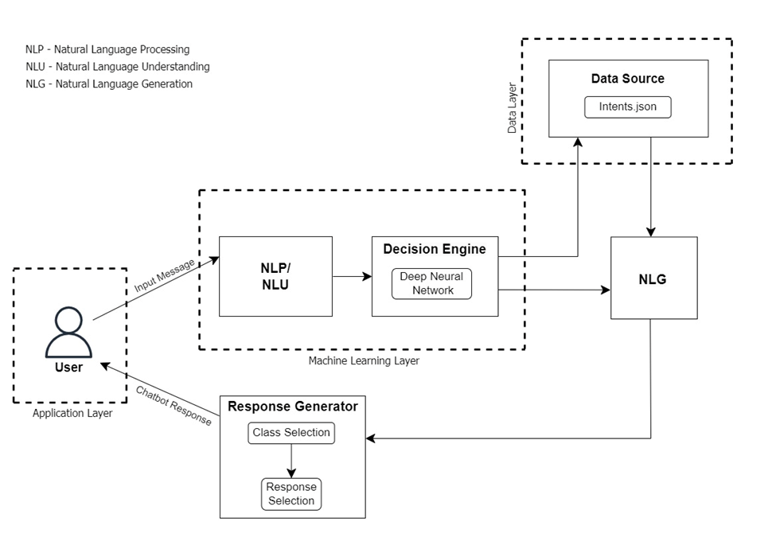

## b. Input Data

For this system, as data we will use a .JSON (JavaScript Object Notation) file to define specific keywords that the chatbot will recognize and use to determine how to respond. This system doesn’t require to download any huge datasets because it’s a straightforward chatbot. Here we shall only make use of data that we have created since it’s a closed domain retrieval-based chatbot.

The JSON file includes intents, for each intent there is a tag, question patterns, responses, and a context. This file generates a number of messages that the user is probably going to input and maps them to a group of appropriate answers. Each dictionary in the file has a tag that identifies the group to which each message belongs. With the use of this data, we will train a neural network to identify a sentence of words and classify it as one of the tags in our file. Then a response will be selected from those groups and be presented it to the user. The more tags, responses, and patterns we provide to the chatbot, the more advanced and sophisticated it will become.

The data needs to be preprocessed in a specific way before it can be used in this system’s model. Extracting the data including patterns of which class or tag they belong to from the JSON file and storing all the unique words from those patterns in some blank lists is the first step.

Then after extracting all the data by looping through the JSON file we have to convert each pattern into a list of words using nltk.word_tokenizer instead of having them as strings. Then add the patterns and its associated tag into the relevant lists.

Then the data must be subjected to the word stemming process to reduce the vocabulary of the model and attempt to find more general meaning behind sentences. Here, the goal is to find the root of the word. As an example word “let’s” stem will be “let” and the word “running” would have the stem of “run”.

After creating a unique list of stemmed words, the final step of data preprocessing is to create a bag of words representation. As it is well known, numerical input is necessary for neural networks and machine learning algorithms. Therefore, the list of strings won't work.

We'll use a list with the length of the number of items in the model's vocabulary to represent each sentence. A word from our vocabulary will be represented by each slot in the list. If a word is listed at position 1, it means that it is present in our sentence; if it is listed at place 0, it is not. We refer to this as a "bag of words" because we don't know the exact order in which the words appear in the phrase; instead, we only know that they are there in the vocabulary model.

# Importing modules and loading data

You can download the intents.json file from here - https://drive.google.com/file/d/16mBw-UejDdN1x4A-3YAvY3mr1jqAef7r/view?usp=sharing

```python
import nltk
from nltk.stem.lancaster import LancasterStemmer
stemmer = LancasterStemmer()
nltk.download('punkt')

import numpy as np
import tflearn
import tensorflow as tf
import random as rd
import json
import matplotlib.pyplot as plt
import pickle

with open("intents.json") as file:    #Loading data from the json file
    data = json.load(file)
```

```
WARNING:tensorflow:From C:\Users\Thiviru\AppData\Roaming\Python\Python39\site-packages\tensorflow\python\compat\v2_compat.py:107: disable_resource_variables (from tensorflow.python.ops.variable_scope) is deprecated and will be removed in a future version.
Instructions for updating:
non-resource variables are not supported in the long term
curses is not supported on this machine (please install/reinstall curses for an optimal experience)
```

# Extracting Data

```python
    words = []       #Creating blank lists to store unique values
    labels = []
    docs_x = []
    docs_y = []

    for intent in data["intents"]:
        for pattern in intent["patterns"]:
            wrds = nltk.word_tokenize(pattern)  #Converting strings into a list of words
            words.extend(wrds)
            docs_x.append(wrds)            #Adding each pattern into docs_x list
            docs_y.append(intent["tag"])   #Adding its associated tag into docs_y list

        if intent["tag"] not in labels:
            labels.append(intent["tag"])
```

# Word Stemming

```python
words = [stemmer.stem(w.lower()) for w in words if w != "?"]  #Removing duplicate elements while stemming the words
words = sorted(list(set(words)))    #Creating a unique list of stemmed words

labels = sorted(labels)
```

# Bag of words

```python
training = []
output = []

out_empty = [0 for _ in range(len(labels))]

#Conveting the strings to numerals, One hot encoding

for x, doc in enumerate(docs_x):
    bag = []

    wrds = [stemmer.stem(w.lower()) for w in doc]

    for w in words:
        if w in wrds:
            bag.append(1)
        else:
            bag.append(0)

    output_row = out_empty[:]
    output_row[labels.index(docs_y[x])] = 1

    training.append(bag)
    output.append(output_row)
```

```python
training = np.array(training)    #Converting the training data and output to numpy arrays
output = np.array(output)
```

# Model Development

```python
#Building the Neural Network

tf.compat.v1.reset_default_graph()

net = tflearn.input_data(shape=[None, len(training[0])])
net = tflearn.fully_connected(net, 8)
net = tflearn.fully_connected(net, 8)
net = tflearn.fully_connected(net, len(output[0]), activation="softmax")
net = tflearn.regression(net)

model = tflearn.DNN(net)
```

```
WARNING:tensorflow:From C:\Users\Thiviru\AppData\Roaming\Python\Python39\site-packages\tflearn\initializations.py:164: calling TruncatedNormal.__init__ (from tensorflow.python.ops.init_ops) with dtype is deprecated and will be removed in a future version.
Instructions for updating:
Call initializer instance with the dtype argument instead of passing it to the constructor
```

# Training and Saving the Model

```python
# Define model and setup tensorboard
model = tflearn.DNN(net, tensorboard_dir='tflearn_logs')

# Start training
history = model.fit(training, output, n_epoch=1000, batch_size=8, show_metric=True)
model.save("model.tflearn")
```

```
Training Step: 15999  | time: 0.027s
| Adam | epoch: 1000 | loss: 0.00000 - acc: 0.9955 -- iter: 120/126
Training Step: 16000  | time: 0.032s
| Adam | epoch: 1000 | loss: 0.00000 - acc: 0.9959 -- iter: 126/126
--
INFO:tensorflow:C:\Users\Thiviru\Documents\submit\model.tflearn is not in all_model_checkpoint_paths. Manually adding it.
```

# Creating Predictions

```python
def bag_of_words(s, words):
    bag = [0 for _ in range(len(words))]

    s_words = nltk.word_tokenize(s)
    s_words = [stemmer.stem(word.lower()) for word in s_words]

    for se in s_words:
        for i, w in enumerate(words):
            if w == se:
                bag[i] = 1

    return np.array(bag)


def chat():
    print("Start talking with the bot (type quit to stop)!")
    while True:
        inp = input("You: ")
        if inp.lower() == "quit":
            break

        results = model.predict([bag_of_words(inp, words)])[0]  #Probability of giving correct response
        results_index = np.argmax(results)   #Choosing the largest number from the probability
        tag = labels[results_index]

        if results[results_index] > 0.7:
            for tg in data["intents"]:
                if tg['tag'] == tag:
                    responses = tg['responses']

            print(rd.choice(responses))
        else:
            print("I don't quite understand. Try again or ask a different quesion")

chat()
```

[output not shown]

# Testing

There are several methods for testing chatbots, such as RPA (Robotic Process Automation), security testing, and UTF (Unit Test Framework) testing. Additionally, there are tools like Botium that can be used to test chatbots. In chatbot testing there are two main ways of testing approaches that can be done.

1. Manual testing – Manually testing each and every intent and event, though it requires a lot of time to test the main point is understanding of chatbot what users want and identify intent.
2. Auto testing – Testing scenarios which are conducted by Selenium, Browserstack, Botium

While testing these chatbot we have to keep in track of certain elements in process like conversational design testing where conversational flow and intent, training and response is tested. Entities testing where keywords taken from the training phrases are tested. Fulfillment testing where the bot needs to request the information to fulfill the user request is tested and finally user acceptance testing where the overall quality of the chatbot is being tested.

In this scenario since its a straightforward chatbot with a limited number of data a manual testing was being conducted. After training the model with training data and saving it into a file we are getting a set test data and reloading the pre trained model from the file for this test to work we need to clean the test data set and have them pre processed to a bag of words. And finally to test out if the model is working optimally we can type a word that is this dataset which will return some binary values as a response since it’s in BoW state and keep changing the word with other words in the dataset and see how the binary value changes accordingly which will indicate that the test is successful.

# Testing the model

```python
pickle.dump( {'words':words, 'classes':labels, 'train_x':training, 'train_y':output}, open( "training_data", "wb" ) )

data = pickle.load( open( "training_data", "rb" ) )
words = data['words']
classes = data['classes']
train_x = data['train_x']
train_y = data['train_y']

#Reopening the intents file as testing data
import json
with open('intents.json') as json_data:
    intents = json.load(json_data)

#Reloading the model we trained earlier

model.load('./model.tflearn')

def clean_up_sentence(sentence):

    sentence_words = nltk.word_tokenize(sentence)

    sentence_words = [stemmer.stem(word.lower()) for word in sentence_words]
    return sentence_words

# return bag of words array
def bow(sentence, words, show_details=False):

    sentence_words = clean_up_sentence(sentence)
    bag = [0]*len(words)
    for s in sentence_words:
        for i,w in enumerate(words):
            if w == s:
                bag[i] = 1
                if show_details:
                    print ("found in bag: %s" % w)

    return(np.array(bag))

#Running a test that will return binary values as a response

p = bow("hello", words)
print(p)
```

```
INFO:tensorflow:Restoring parameters from C:\Users\Thiviru\Documents\submit\model.tflearn
[0 0 0 0 0 0 0 0 0 0 0 0 0 0 0 0 0 0 0 0 0 0 0 0 0 0 0 0 0 0 0 0 0 0 0 0 0
 0 0 0 0 0 0 0 0 0 0 0 0 0 0 0 0 0 0 0 0 0 0 0 0 0 0 0 0 0 0 0 0 0 0 0 0 0
 0 0 0 0 0 0 0 1 0 0 0 0 0 0 0 0 0 0 0 0 0 0 0 0 0 0 0 0 0 0 0 0 0 0 0 0 0
 0 0 0 0 0 0 0 0 0 0 0 0 0 0 0 0 0 0 0 0 0 0 0 0 0 0 0 0 0 0 0 0 0 0 0 0 0
 0 0 0 0 0 0 0 0 0 0 0 0 0 0 0 0 0 0 0 0 0 0 0 0 0 0 0 0 0 0 0 0 0 0 0 0 0
 0 0 0 0 0 0 0 0 0 0 0 0 0 0 0 0]
```

When comparing the actual and correct results produced by the chatbot implementation we can consider the following test cases.

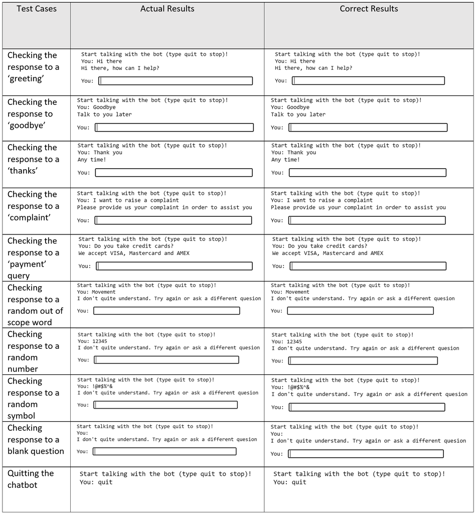

# Evaluate results

As a machine learning model, the accuracy of a chatbot will vary based on a variety of variables, such as the quality and quantity of training data, the difficulty of the task being performed, and the model's particular architecture and hyperparameters. Additionally, a number of metrics, including precision, recall, and R2 score, can be used to analyze chatbots and compare the effectiveness of various chatbots and versions of the same chatbot. One way to evaluate the accuracy of a chatbot is to perform test cases. This can involve providing a set of inputs (i.e. questions or statements) to the chatbot and comparing its output to a set of expected outputs. Test cases can be designed to cover a wide range of scenarios, including edge cases and common use cases, in order to get a comprehensive understanding of the chatbot's performance.

By performing the above test cases it is clear that the model is working optimally since the actual output and the expected correct output is almost similar to each other which means the model is identifying intent of each class and giving them a proper response to what the user is asking also if the question is out of scope or the probability of that question being similar to a class in the dataset is low the chatbot will handle that by asking the user to try again.

Other than ensuring that the chatbot is performing as expected it also helps to improve overall performance by identifying errors, allowing for qualitative measurement and helping to identify edge cases where rare use cases are being tested. So by considering all this it is evident that this prototype is performing at its level best with the data that it has to produce the most accurate and correct results.

When interpreting after applying these results and evaluate how well the model performed first we evaluated the model by predicting 20 output data. And as you can see below the model performance was very accurate since the predicted data figures and actual results are very similar to each other.

```python
#Evaluating the model with the output

[np.argmax(i) for i in model.predict(training)[:20]]
```

```
[12, 2, 12, 12, 12, 12, 12, 12, 11, 11, 11, 11, 11, 11, 11, 11, 34, 34, 34, 34]
```

```python
[np.argmax(i) for i in output][:20]
```

```
[12,
 12,
 12,
 12,
 12,
 12,
 12,
 12,
 11,
 11,
 11,
 11,
 11,
 11,
 11,
 11,
 34,
 34,
 34,
 34]
```

Additionally, a number of metrics were used to further evaluate the accuracy of this model which are mean absolute error, mean squared error, root mean squared error and r2 score. For all these metrics this model was able archive above average scores including low error values and a r2 score of 96%.

```python
#Evaluating the model with metrics

from sklearn.metrics import mean_absolute_error
from sklearn.metrics import mean_squared_error
from sklearn.metrics import r2_score
from sklearn.metrics import explained_variance_score
from math import sqrt

result = model.predict(training)
result = (result.tolist())
rounded_result = [round(num[0]) for num in result]

accuracy = mean_absolute_error(train_y, result) #[true_val,presicted_val]
acc = mean_squared_error(output, result)
r2score_result = r2_score(output, result)

print('Mean absolute error:', accuracy)
print('Mean squared Error:', acc)
print('Root Mean Square Error:', sqrt(acc))
print('r2score:',r2score_result)
```

```
Mean absolute error: 0.0008943206649992238
Mean squared Error: 0.00022341141943887078
Root Mean Square Error: 0.014946953516983679
r2score: 0.9680771171441664
```

# References and Bibliography

Kaur, J., & Bhattacharya, P. (2017). A survey on chatbot. International Journal of Computer Science and Mobile Computing, 6(2), 5-11.

Bhattacharya, P., & Kaur, J. (2016). A review on chatbot: Architecture, design and challenges. International Journal of Engineering and Computer Science, 5(8), 19027-19032.

Tavakoli, M., & Alani, H. (2018). A survey of chatbots. ACM Computing Surveys (CSUR), 51(3), 1-40.

Chung, J., & Zong, C. (2018). A survey of chatbot technologies. In 2018 International Conference on Advanced Technologies for Communications (ATC) (pp. 1-6). IEEE.

Bhagwat, V.A. (2018). Deep Learning for Chatbots [Master of Science]. San Jose, CA, USA: San Jose State University. Available from https://doi.org/10.31979/etd.9hrt-u93z [Accessed 6 January 2023].

Brown, T.B. et al. (2020). Language Models are Few-Shot Learners. Available from https://doi.org/10.48550/arXiv.2005.14165 [Accessed 6 January 2023].

Cui, L. et al. (2017). SuperAgent: A Customer Service Chatbot for E-commerce Websites. Proceedings of ACL 2017, System Demonstrations. 2017. Vancouver, Canada: Association for Computational Linguistics, 97–102. Available from https://doi.org/10.18653/v1/P17-4017 [Accessed 6 January 2023].

Mahmoud, M. and Kumar, R. (2020). A Review on Chatbot Design and Implementation Techniques. International Journal of Engineering and Technology, 7, 2791.

Michael. (2019). How Chatbots Use Artificial Intelligence to Satisfy Customers Faster & Easier than Ever Before. Freshdesk Blogs. Available from https://www.freshworks.com/freshdesk/customer-support/customer-satisfaction-ai-chatbots-blog/ [Accessed 6 January 2023].

Nuruzzaman, M. and Hussain, O.K. (2018). A Survey on Chatbot Implementation in Customer Service Industry through Deep Neural Networks. 2018 IEEE 15th International Conference on e-Business Engineering (ICEBE). October 2018. 54–61. Available from https://doi.org/10.1109/ICEBE.2018.00019.

Oracle. (2014). What is a Chatbot? Available from https://www.oracle.com/uk/chatbots/what-is-a-chatbot/ [Accessed 6 January 2023].

Shah, D. (2020). Generative chatbots using the seq2seq model! Medium. Available from https://towardsdatascience.com/generative-chatbots-using-the-seq2seq-model-d411c8738ab5 [Accessed 6 January 2023].

Wallace, R. (1995). ALICE: A natural language robot. Communications of the ACM, 38(11), 61-72.

Adam, M., Wessel, M. & Benlian, A. AI-based chatbots in customer service and their effects on user compliance. Electron Markets 31, 427–445 (2021). https://doi.org/10.1007/s12525-020-00414-7

Bhagwat, Vyas Ajay, "Deep Learning for Chatbots" (2018). Master's Projects. 630. DOI: https://doi.org/10.31979/etd.9hrt-u93z https://scholarworks.sjsu.edu/etd_projects/630

Techlabs M., 2017. What Are The Inner Workings of a Chatbot? – Chatbots Magazine. [ONLINE]. Available from: https://chatbotsmagazine.com/what is-the-working-of-a-chatbot-e99e6996f51c. [Accessed: 22 May 2019].

Hubtype, 2018. Rule-Based vs AI Chatbots. [ONLINE].Available from: https://www.hubtype.com/blog/rule-based-vs-ai-chatbots/. [Accessed: 22 May 2019].

Weizenbaum, J. (1966). ELIZA - A Computer Program For the Study of Natural Language Communication Between Man and Machine. Communications of the ACM, 9(1), 36-45.